# Taxonomic Data QC

Author

Joe Boktor

Published

October 6, 2023

## Helpful Resources:

- [phyloseq docs](https://joey711.github.io/phyloseq/preprocess.html)
- [microbiome docs](https://microbiome.github.io/tutorials/cleaning_taxonomy_table.html)
- [microbiomeutilties docs](https://microsud.github.io/microbiomeutilities/articles/microbiomeutilities.html)

## Data Quality Control

This notebook displays some common data quality control methods and visualizations.

```r
cran_packages <-
  c("strex",
    "knitr")

missing_cran_packages <-
  cran_packages[!(cran_packages %in% installed.packages()[, "Package"])]

if (length(missing_cran_packages)) {
  install.packages(missing_cran_packages)
}

# Installing other misc packages available via github
if (!require(microbiomeutilities)){
  devtools::install_github("microsud/microbiomeutilities")
}

suppressMessages({
  library(tidyverse)
  library(future)
  library(furrr)
  library(data.table)
  library(KEGGREST)
  library(pathview)
  library(glue)
  library(vegan)
  library(phyloseq)
  library(MGnifyR)
  library(DT)
  library(microbiome)
  library(microbiomeutilities)
  library(strex)
  library(ggrepel)
  })

# set the working directory as the path of this project folder (not the notebook subfolder)
wkdir <- "/Users/josephboktor/Documents/analyses/Bi270A_Metagenomics_Tutorials"
```

Loading in your previously saved phyloseq object from notebook 01

```r
ps <- readRDS(
  glue("{wkdir}/data/interim/2023-10-09_phyloseq.rds")
)
```

### Intro to phyloseq object manipulation

Pulling metadata from a phyloseq object

```r
metadata_df <- microbiome::meta(ps)
metadata_df %>% glimpse()
```

```
Rows: 24
Columns: 43
$ analysis_analysis.status                                         <chr> "comp…
$ analysis_pipeline.version                                        <chr> "5.0"…
$ analysis_accession                                               <chr> "MGYA…
$ analysis_experiment.type                                         <chr> "asse…
$ analysis_is.private                                              <chr> "FALS…
$ analysis_complete.time                                           <chr> "2022…
$ analysis_instrument.platform                                     <chr> "ILLU…
$ analysis_instrument.model                                        <chr> "Illu…
$ analysis_Submitted.nucleotide.sequences                          <chr> "1408…
$ analysis_Nucleotide.sequences.after.format.specific.filtering    <chr> "1408…
$ analysis_Nucleotide.sequences.after.length.filtering             <chr> "1408…
$ analysis_Nucleotide.sequences.after.undetermined.bases.filtering <chr> "1408…
$ analysis_Reads.with.predicted.CDS                                <chr> "1404…
```

[output cut: 30 more lines]

Pulling OTU abundance count profiles

```r
otu_df <- microbiome::abundances(ps)
otu_df %>% DT::datatable(options = list(scrollX = TRUE))
```

|  | MGYA00615918 | MGYA00615929 | MGYA00615930 | MGYA00615931 | MGYA00615932 | MGYA00615933 | MGYA00615934 | MGYA00615935 | MGYA00616693 | MGYA00616694 | MGYA00616695 | MGYA00616696 | MGYA00616697 | MGYA00616698 | MGYA00616699 | MGYA00616700 | MGYA00616701 | MGYA00616702 | MGYA00616703 | MGYA00616704 | MGYA00616705 | MGYA00616706 | MGYA00616707 | MGYA00616708 |
| --- | --- | --- | --- | --- | --- | --- | --- | --- | --- | --- | --- | --- | --- | --- | --- | --- | --- | --- | --- | --- | --- | --- | --- | --- |
| 5820 | 7 | 6 | 10 | 10 | 5 | 10 | 10 | 10 | 19 | 14 | 21 | 13 | 21 | 19 | 22 | 9 | 18 | 10 | 18 | 10 | 22 | 11 | 11 | 10 |
| 139786 | 1 | 1 | 1 | 1 | 1 | 2 | 2 | 1 | 1 | 1 | 3 | 1 | 1 | 1 | 2 | 1 | 1 | 1 | 1 | 1 | 1 | 1 | 1 | 1 |
| 53573 | 1 | 2 | 2 | 0 | 2 | 1 | 2 | 0 | 1 | 1 | 0 | 0 | 2 | 0 | 1 | 0 | 0 | 1 | 0 | 2 | 0 | 4 | 2 | 1 |
| 152544 | 1 | 2 | 1 | 1 | 1 | 0 | 0 | 1 | 0 | 0 | 0 | 2 | 0 | 1 | 1 | 1 | 0 | 1 | 1 | 0 | 0 | 1 | 0 | 0 |
| 49655 | 2 | 2 | 2 | 2 | 2 | 2 | 2 | 2 | 2 | 2 | 2 | 2 | 2 | 2 | 2 | 2 | 2 | 2 | 2 | 2 | 2 | 2 | 2 | 2 |
| 57430 | 1 | 1 | 1 | 1 | 1 | 1 | 1 | 1 | 1 | 1 | 1 | 1 | 1 | 1 | 1 | 1 | 1 | 1 | 1 | 1 | 1 | 1 | 1 | 1 |
| 196428 | 6 | 6 | 7 | 2 | 9 | 4 | 4 | 7 | 9 | 4 | 14 | 7 | 7 | 10 | 4 | 7 | 6 | 7 | 12 | 9 | 11 | 5 | 9 | 3 |
| 169091 | 1 | 0 | 0 | 0 | 0 | 0 | 0 | 1 | 0 | 0 | 0 | 0 | 0 | 0 | 0 | 0 | 0 | 1 | 0 | 0 | 0 | 0 | 0 | 0 |
| 52683 | 2 | 3 | 5 | 3 | 3 | 2 | 2 | 5 | 5 | 4 | 2 | 2 | 3 | 2 | 2 | 1 | 4 | 2 | 1 | 1 | 3 | 3 | 2 | 5 |
| 77379 | 2 | 0 | 0 | 0 | 1 | 1 | 0 | 4 | 2 | 2 | 4 | 0 | 2 | 4 | 3 | 0 | 2 | 1 | 2 | 3 | 3 | 0 | 0 | 6 |

[output cut: 101 more lines]

Viewing your taxonomic rank annotations. Analysis of SSU regions of taxa will lead to variable precision in taxonomic annotation. Some sequences will provide species/strain level clarity while others may only provide sufficient resolution to determine the Phylum of the taxa.

```r
ps %>%
  tax_table() %>%
  DT::datatable(options = list(scrollX = TRUE))
```

|  | Species | Kingdom | Phylum | Class | Order | Family | Genus |
| --- | --- | --- | --- | --- | --- | --- | --- |
| 5820 | sBacteria |  |  |  |  |  |  |
| 139786 | sBacteria |  | Actinobacteria | Actinobacteria | Bifidobacteriales | Bifidobacteriaceae | Bifidobacterium |
| 53573 | Streptomyces_sp._NRRL_F-6677 |  | Actinobacteria | Actinobacteria | Streptomycetales | Streptomycetaceae | Streptomyces |
| 152544 | sBacteria |  | Actinobacteria | Coriobacteriia | Coriobacteriales | Coriobacteriaceae |  |
| 49655 | sBacteria |  | Bacteroidetes | Bacteroidia |  |  |  |
| 57430 | sBacteria |  | Bacteroidetes | Bacteroidia | Bacteroidales | Rikenellaceae | Alistipes |
| 196428 | sBacteria |  | Firmicutes |  |  |  |  |
| 169091 | sBacteria |  | Firmicutes | Bacilli | Lactobacillales |  |  |
| 52683 | sBacteria |  | Firmicutes | Bacilli | Lactobacillales | Lactobacillaceae | Lactobacillus |
| 77379 | sBacteria |  | Firmicutes | Clostridia |  |  |  |

[output cut: 101 more lines]

Filtering a phyloseq object by available metadata

```r
# filtering character columns by exact match
subset_samples(ps, assembly_accession = ERZ4883048)
```

```
phyloseq-class experiment-level object
otu_table()   OTU Table:         [ 111 taxa and 24 samples ]
sample_data() Sample Data:       [ 24 samples by 43 sample variables ]
tax_table()   Taxonomy Table:    [ 111 taxa by 7 taxonomic ranks ]
```

```r
# filtering character columns by string matching / regex
subset_samples(ps, grepl("Ranger Classic", sample_sample.name))
```

```
phyloseq-class experiment-level object
otu_table()   OTU Table:         [ 111 taxa and 12 samples ]
sample_data() Sample Data:       [ 12 samples by 43 sample variables ]
tax_table()   Taxonomy Table:    [ 111 taxa by 7 taxonomic ranks ]
```

```r
# filtering numeric values
subset_samples(ps, analysis_Nucleotide.sequences.after.length.filtering > 175000)
```

```
phyloseq-class experiment-level object
otu_table()   OTU Table:         [ 111 taxa and 12 samples ]
sample_data() Sample Data:       [ 12 samples by 43 sample variables ]
tax_table()   Taxonomy Table:    [ 111 taxa by 7 taxonomic ranks ]
```

```r
# filtering phyloseq object by a mix of logical conditions
subset_samples(
  ps,
  grepl("Ranger Classic", sample_sample.name) &
    analysis_Nucleotide.sequences.after.length.filtering > 175000
)
```

```
phyloseq-class experiment-level object
otu_table()   OTU Table:         [ 111 taxa and 2 samples ]
sample_data() Sample Data:       [ 2 samples by 43 sample variables ]
tax_table()   Taxonomy Table:    [ 111 taxa by 7 taxonomic ranks ]
```

### Formatting your phyloseq metadta

Adding / Editing metadata

```r
# In this example set, we see that the sample names contain some useful group descriptive metadata. It would be very helpful to have this information in separate columns to make subsetting our data easier in the future.

# using the convient strex package, we will partition these descriptions into different column vectors
sample_data(ps)$group <- metadata_df$sample_sample.name %>% strex::str_after_first(": ")
sample_data(ps)$breed <- sample_data(ps)$group %>% strex::str_before_first(",")
sample_data(ps)$diet <- sample_data(ps)$group %>% strex::str_after_first(", ")

ps %>% meta() %>%
  select(sample_sample.name, group, breed, diet) %>%
  DT::datatable(options = list(scrollX = TRUE))
```

|  | sample_sample.name | group | breed | diet |
| --- | --- | --- | --- | --- |
| MGYA00615918 | Chicken 3 cecal contents: Ranger Classic, Vegetable diet | Ranger Classic, Vegetable diet | Ranger Classic | Vegetable diet |
| MGYA00615929 | Chicken 1 cecal contents: Ranger Classic, Fish meal diet | Ranger Classic, Fish meal diet | Ranger Classic | Fish meal diet |
| MGYA00615930 | Chicken 17 cecal contents: Ranger Classic, Fish Meal diet | Ranger Classic, Fish Meal diet | Ranger Classic | Fish Meal diet |
| MGYA00615931 | Chicken 23 cecal contents: Ranger Classic, Vegetable diet | Ranger Classic, Vegetable diet | Ranger Classic | Vegetable diet |
| MGYA00615932 | Chicken 13 cecal contents: Ranger Classic, Fish Meal diet | Ranger Classic, Fish Meal diet | Ranger Classic | Fish Meal diet |
| MGYA00615933 | Chicken 21 cecal contents: Ranger Classic, Fish Meal diet | Ranger Classic, Fish Meal diet | Ranger Classic | Fish Meal diet |
| MGYA00615934 | Chicken 2 cecal contents: Ross 308, Fish meal diet | Ross 308, Fish meal diet | Ross 308 | Fish meal diet |
| MGYA00615935 | Chicken 5 cecal contents: Ranger Classic, Fish meal diet | Ranger Classic, Fish meal diet | Ranger Classic | Fish meal diet |
| MGYA00616693 | Chicken 12 cecal contents: Ross 308, Vegetable diet | Ross 308, Vegetable diet | Ross 308 | Vegetable diet |
| MGYA00616694 | Chicken 8 cecal contents: Ross 308, Vegetable diet | Ross 308, Vegetable diet | Ross 308 | Vegetable diet |

[output cut: 14 more lines]

Reformatting your taxonomy labels.

```r
# How taxa are currently named in our phyloseq object
head(taxa(ps))
```

```
[1] "5820"   "139786" "53573"  "152544" "49655"  "57430"
```

```r
# reformatting to view the best level of resolution provided by annonation
ps <- microbiomeutilities::format_to_besthit(ps)
head(taxa(ps))
```

```
[1] "5820:k__sBacteria"           "139786:Bifidobacterium"
[3] "53573:Streptomyces"          "152544:g__Coriobacteriaceae"
[5] "49655:o__Bacteroidia"        "57430:Alistipes"
```

### Exploring your data

Visualizing read quality summary stats

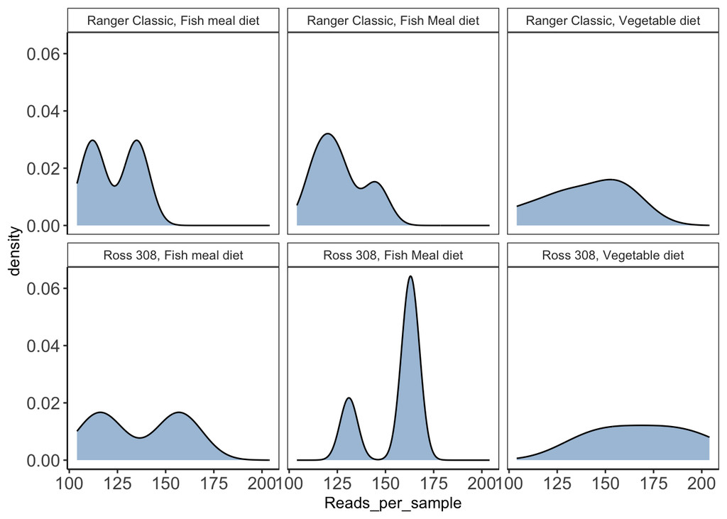

```r
microbiomeutilities::plot_read_distribution(
  ps, groups = "group", plot.type = "density"
  ) +
  theme_biome_utils()
```

Visualizing prevalence / abundance relationship

```r
set.seed(42)
# this command is described in more detail below
asv_ps <- microbiome::transform(ps, "compositional")
p_abund_vs_prev <- plot_abund_prev(
  asv_ps,
  label.core = TRUE,
  color = "blue",
  mean.abund.thres = 0.01,
  mean.prev.thres = 0.99,
  dot.opacity = 0.7,
  label.size = 4,
  label.opacity = 1.0,
  nudge.label = -0.15,
  bs.iter = 99,
  size = nsamples(asv_ps),
  replace = TRUE,
  label.color = "black"
) +
  geom_vline(xintercept = 0.95, lty = "dashed", alpha = 0.7) +
  geom_hline(yintercept = 0.01, lty = "dashed", alpha = 0.7)
```

```
Make sure to set.seed!!!
```

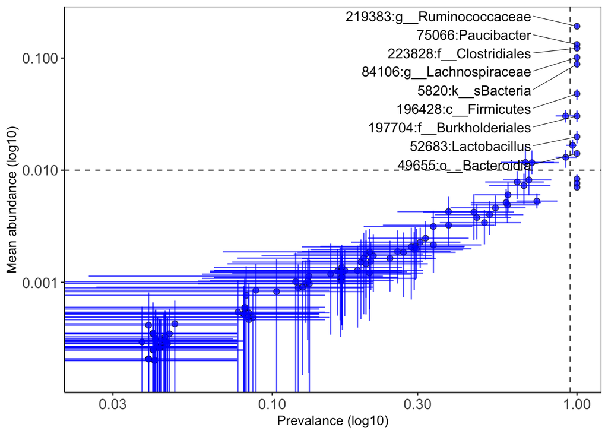

```r
p_abund_vs_prev
```